# Intelligence des dragons

Un tutoriel pour utiliser les modèles linéaires à effets aléatoires.

Antoine Bichat https://abichat.github.io  
2019-08-30

# Introduction

```r
library(tidyverse)
library(car)
library(broom)
library(flextable)

theme_set(theme_bw())
```

Extrait des données

| testScore | bodyLength | mountainRange | site |
| --- | --- | --- | --- |
| 76.930 | 215.294 | Central | b |
| 53.496 | 233.653 | Julian | c |
| 64.161 | 226.274 | Julian | c |
| 28.797 | 200.452 | Ligurian | a |
| 29.836 | 208.771 | Ligurian | a |
| 77.821 | 198.909 | Maritime | b |
| 78.669 | 208.911 | Maritime | b |
| 26.922 | 179.103 | Southern | b |
| 24.616 | 186.469 | Southern | c |
| 25.646 | 189.653 | Southern | c |

Statistiques univariées

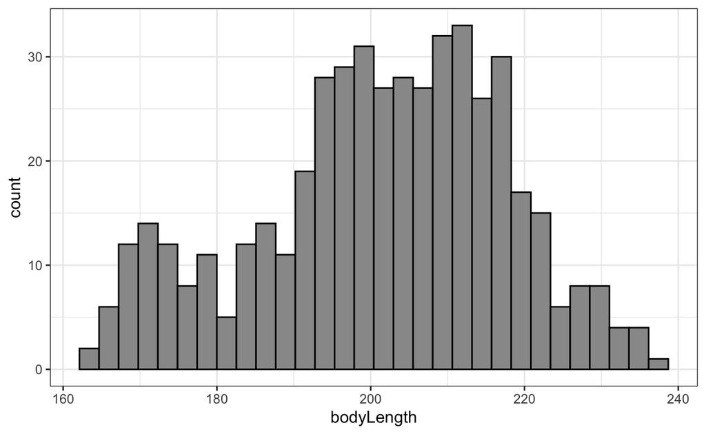

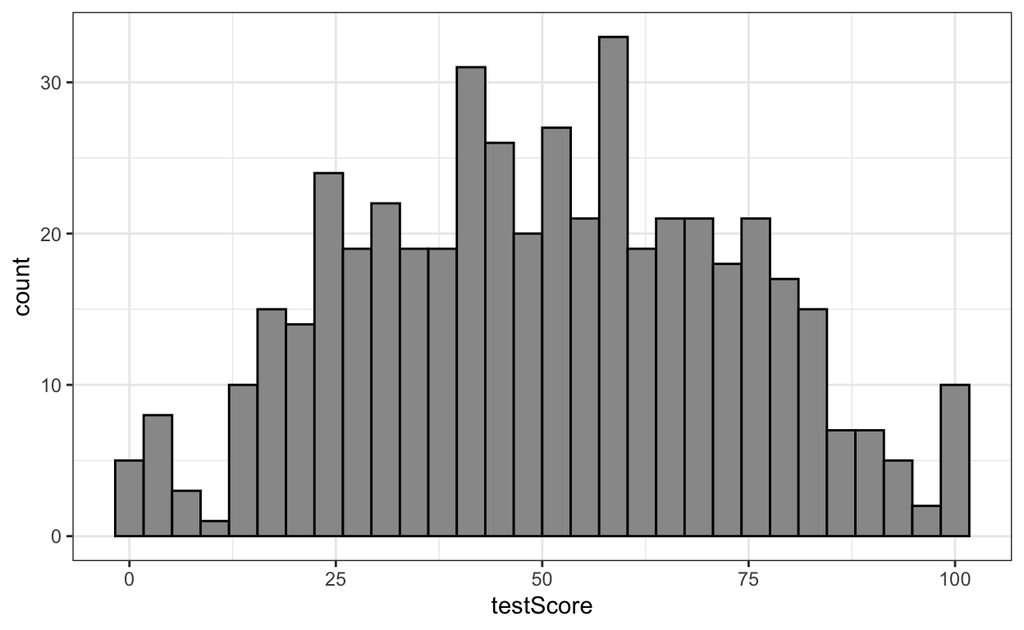

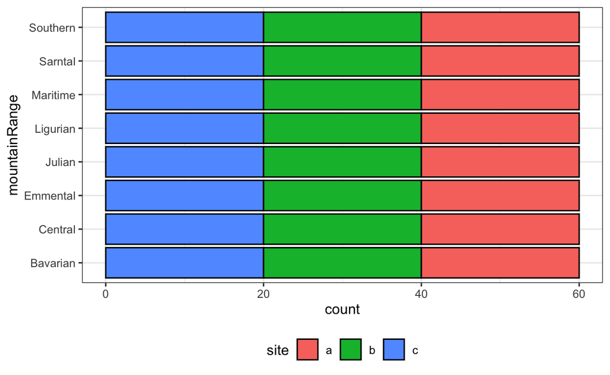

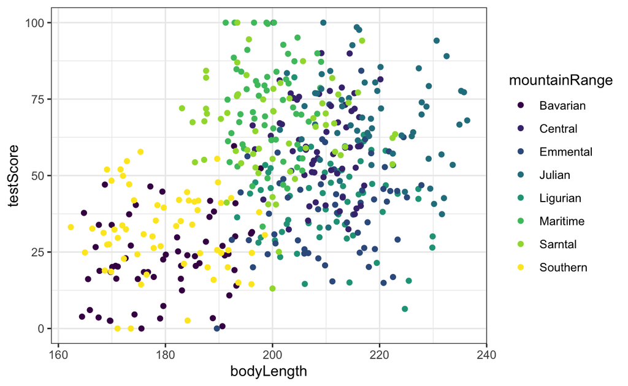

# Analyse statistique

## Modèle linéaire simple

```r
model_simple <- lm(testScore ~ bodyLength, data = dragons)
```

| term | estimate | std.error | statistic | p.value |
| --- | --- | --- | --- | --- |
| (Intercept) | -61.318 | 12.067 | -5.081 | 0.000 |
| bodyLength | 0.555 | 0.060 | 9.287 | 0.000 |

La longueur du dragon explique son intelligence.

## ANCOVA

```r
model_ancova <- lm(testScore ~ bodyLength + mountainRange, data = dragons)
```

On regarde les coefficients de chaque variable via `broom::tidy()`.

| term | estimate | std.error | statistic | p.value |
| --- | --- | --- | --- | --- |
| (Intercept) | 20.831 | 14.472 | 1.439 | 0.151 |
| bodyLength | 0.013 | 0.080 | 0.159 | 0.874 |
| mountainRangeCentral | 36.583 | 3.599 | 10.164 | 0.000 |
| mountainRangeEmmental | 16.209 | 3.697 | 4.385 | 0.000 |
| mountainRangeJulian | 45.115 | 4.190 | 10.767 | 0.000 |
| mountainRangeLigurian | 17.748 | 3.674 | 4.831 | 0.000 |
| mountainRangeMaritime | 49.881 | 3.139 | 15.890 | 0.000 |
| mountainRangeSarntal | 41.978 | 3.197 | 13.130 | 0.000 |
| mountainRangeSouthern | 8.520 | 2.731 | 3.119 | 0.002 |

On fait une analyse de la variance de type II via `car::Ancova()`.

| term | sumsq | df | statistic | p.value |
| --- | --- | --- | --- | --- |
| bodyLength | 5.653 | 1.000 | 0.025 | 0.874 |
| mountainRange | 109415.981 | 7.000 | 69.844 | 0.000 |
| Residuals | 105407.810 | 471.000 |  |  |

La longueur du dragon n’est plus significative pour expliquer son intelligence si on prend en compte la région d’où il vient.

## Modèle mixte

On utilise le package **lme4** pour faire du modèle mixte et **broom.mixed** pour mettre en forme les résultats.

```r
library(lme4)
library(broom.mixed)
```

```r
model_mixed <- lmer(testScore ~ bodyLength + (1|mountainRange),
                    data = dragons, REML = TRUE)
```

On regade `tidy(model_mixed)` et `glance(model_mixed)`.

| effect | group | term | estimate | std.error | statistic |
| --- | --- | --- | --- | --- | --- |
| fixed |  | (Intercept) | 43.709 | 17.135 | 2.551 |
| fixed |  | bodyLength | 0.033 | 0.079 | 0.422 |
| ran_pars | mountainRange | sd__(Intercept) | 18.430 |  |  |
| ran_pars | Residual | sd__Observation | 14.960 |  |  |

| sigma | logLik | AIC | BIC | REMLcrit | df.residual |
| --- | --- | --- | --- | --- | --- |
| 14.960 | -1995.601 | 3999.203 | 4015.898 | 3991.203 | 476 |

On va comparer ce modèle avec le modèle qui ne contient pas `bodyLength`.

```r
model_mixed_null <- lmer(testScore ~ 1 + (1|mountainRange),
                         data = dragons, REML = TRUE)
```

Puis on fait une anova de type I via `anova()`.

| term | df | AIC | BIC | logLik | deviance | statistic | Chi.Df | p.value |
| --- | --- | --- | --- | --- | --- | --- | --- | --- |
| model_mixed_null | 3.000 | 3999.685 | 4012.206 | -1996.843 | 3993.685 |  |  |  |
| model_mixed | 4.000 | 4001.478 | 4018.173 | -1996.739 | 3993.478 | 0.207 | 1.000 | 0.649 |

La variable n’est pas `bodyLength` n’est pas signifiactive.

## Modèle mixte à effets imbriqués

```r
model_nested <- lmer(testScore ~ bodyLength + (1|mountainRange) + (1|mountainRange:site),
                     data = dragons)
```

| effect | group | term | estimate | std.error | statistic |
| --- | --- | --- | --- | --- | --- |
| fixed |  | (Intercept) | 40.067 | 21.864 | 1.833 |
| fixed |  | bodyLength | 0.051 | 0.104 | 0.494 |
| ran_pars | mountainRange:site | sd__(Intercept) | 4.805 |  |  |
| ran_pars | mountainRange | sd__(Intercept) | 18.099 |  |  |
| ran_pars | Residual | sd__Observation | 14.442 |  |  |

| sigma | logLik | AIC | BIC | REMLcrit | df.residual |
| --- | --- | --- | --- | --- | --- |
| 14.442 | -1987.980 | 3985.961 | 4006.830 | 3975.961 | 475 |

```r
model_nested_null <- lmer(testScore ~ 1 + (1|mountainRange) + (1|mountainRange:site),
                          data = dragons)
```

On fait une anova de type un entre `model_nested` et `model_null`.

| term | df | AIC | BIC | logLik | deviance | statistic | Chi.Df | p.value |
| --- | --- | --- | --- | --- | --- | --- | --- | --- |
| model_nested_null | 4.000 | 3987.054 | 4003.749 | -1989.527 | 3979.054 |  |  |  |
| model_nested | 5.000 | 3988.767 | 4009.636 | -1989.384 | 3978.767 | 0.287 | 1.000 | 0.592 |

La modèle qui contient `bodyLength` n’est pas significativement différent du modèle qui ne le contient pas.

# Notes

## ML / REML

Par défaut, `lmer()` va optimiser `REML` et non pas `ML`. Cependant, lorsqu’on fait `anova()` entre deux modèles, ceux-ci sont recalculés pour être optimisés selon `ML`.

## Prédiction

```r
augment(model_nested, dragons)
```

```
# A tibble: 480 x 15
   testScore bodyLength mountainRange site  .fitted .resid   .hat
       <dbl>      <dbl> <fct>         <fct>   <dbl>  <dbl>  <dbl>
 1     16.1        166. Bavarian      a        20.8  -4.62 0.0426
 2     33.9        168. Bavarian      a        20.9  13.0  0.0412
 3      6.04       166. Bavarian      a        20.8 -14.8  0.0424
 4     18.8        168. Bavarian      a        20.9  -2.04 0.0411
 5     33.9        170. Bavarian      a        21.0  12.9  0.0401
 6     47.0        169. Bavarian      a        20.9  26.1  0.0406
 7      2.56       170. Bavarian      a        21.0 -18.4  0.0402
 8      3.88       164. Bavarian      a        20.7 -16.8  0.0436
 9      3.60       168. Bavarian      a        20.9 -17.3  0.0412
10      7.36       180. Bavarian      a        21.5 -14.1  0.0415
# … with 470 more rows, and 8 more variables: .cooksd <dbl>,
#   .fixed <dbl>, .mu <dbl>, .offset <dbl>, .sqrtXwt <dbl>,
#   .sqrtrwt <dbl>, .weights <dbl>, .wtres <dbl>
```

On a accès aux coefficients via les fonctions `coefficients()` pour les effets fixes et `ranef()` poyr les effets aléatoires.

```r
coefficients(summary(model_nested))
```

```
               Estimate Std. Error   t value
(Intercept) 40.06668461 21.8637262 1.8325643
bodyLength   0.05125933  0.1036823 0.4943882
```

```r
ranef(model_nested)
```

```
$`mountainRange:site`
           (Intercept)
Bavarian:a -2.46727013
Bavarian:b -3.05278011
Bavarian:c  3.73563138
Central:a  -6.38640272
Central:b   0.84540851
Central:c   6.17300467
Emmental:a -3.02659323
Emmental:b  2.29768276
Emmental:c -0.03273956
Julian:a    2.42006297
Julian:b    2.20653823
Julian:c   -3.44048547
Ligurian:a  0.99876652
Ligurian:b -0.84624300
Ligurian:c -0.80816262
Maritime:a -3.67613755
Maritime:b -0.63034533
Maritime:c  5.87130063
Sarntal:a   3.65403133
Sarntal:b  -4.91064701
Sarntal:c   2.27893850
Southern:a -0.68072302
Southern:b  2.18570109
Southern:c -2.70853686

$mountainRange
         (Intercept)
Bavarian  -25.313507
Central     8.965609
Emmental  -10.804657
Julian     16.826065
Ligurian   -9.300801
Maritime   22.198277
Sarntal    14.502523
Southern  -17.073510

with conditional variances for "mountainRange:site" "mountainRange"
```

La prédiction de fait en décomposant additionnant les différentes composantes.

```r
# Ordonné à l'origine
coefficients(summary(model_nested))[1, 1] +
  # Taille des 6 premiers dragons * coefficient de cette variable
  dragons$bodyLength[1:6] * coefficients(summary(model_nested))[2, 1] +
  # Coefficient dû à la montagne (Bavarian pour les 6 premiers)
  ranef(model_nested)$mountainRange["Bavarian", ] +
  # Coefficient dû au site dans la montagne (Bavarian:a pour les 6 premiers)
  ranef(model_nested)$`mountainRange:site`["Bavarian:a", ]
```

```
[1] 20.77181 20.87489 20.78896 20.88136 20.99793 20.93278
```

Et on retouve le même résultat

```r
augment(model_nested, dragons)$.fitted[1:6]
```

```
[1] 20.77181 20.87489 20.78896 20.88136 20.99793 20.93278
```

## Probabilités cririques

Si veut les probabilités critiques pour chaque variable, on besoin de charger le package **lmerTest**.

```r
library(lmerTest)
```

```r
model_mixed <- lmer(testScore ~ bodyLength + (1|mountainRange),
                    data = dragons)
```

| effect | group | term | estimate | std.error | statistic | df | p.value |
| --- | --- | --- | --- | --- | --- | --- | --- |
| fixed |  | (Intercept) | 43.709 | 17.135 | 2.551 | 177.466 | 0.012 |
| fixed |  | bodyLength | 0.033 | 0.079 | 0.422 | 472.667 | 0.673 |
| ran_pars | mountainRange | sd__(Intercept) | 18.430 |  |  |  |  |
| ran_pars | Residual | sd__Observation | 14.960 |  |  |  |  |

| sigma | logLik | AIC | BIC | REMLcrit | df.residual |
| --- | --- | --- | --- | --- | --- |
| 14.960 | -1995.601 | 3999.203 | 4015.898 | 3991.203 | 476 |

La variable `bodyLength` n’est pas significative.

# Conclusion

On a un joli paradoxe de Simpson :)